# Unlocking Insights (I): Analyzing Categorical Data with Cross-Tab and Chi-Squared Test

# Overview of the Content

## Introducing two distinct tools for data analysis with categorical data using R

- Frequency tables
- Chi-squared test

## Case study

- Focused on diversity and inclusion (D&I)
- Sourced from the book [Predictive HR Analytics : Mastering the HR Metric](https://www.amazon.com/Predictive-HR-Analytics-Mastering-Metric/dp/0749473916)
- With data available [here](https://www.koganpage.com/hr-learning-development/predictive-hr-analytics-9780749484446)

## Data preparation and exploration

- Packages: `tidyverse`, `kableExtra`
- Data preparation and exploration
- Creation of cross-tab
- Data visualization
- Chi-squared test

# Problem Statement

## The business needs

A hypothetical company aims to employ scientific methods and procedures to address a significant people problem: gender diversity.

- **Commercial perspective**
  - The organization seeks to foster a greater diversity of thought in senior and strategic discussions.
- **People perspective**
  - The organization wants to assess whether it maintains gender balance by providing positive role models for younger employees.

## The research question

Are women underrepresented in senior leadership roles within the organization?

# Data Preparation and Exploration

## Look at the data - The structure

```r
diversity <- read_csv("../2023-09-14-frequency-tables-and-chi-squared-test/diversity1.csv")
glimpse(diversity)
```

```
Rows: 1,493
Columns: 11
$ BossGender       <dbl> 1, 1, 1, 1, 1, 1, 1, 1, 1, 1, 1, 1, 1, 1, 1, 1, 1, 1,…
$ Gender           <dbl> 1, 1, 1, 1, 1, 1, 1, 1, 1, 1, 1, 1, 1, 1, 1, 1, 2, 2,…
$ JobGrade         <dbl> 6, 5, 5, 3, 6, 7, 6, 5, 6, 6, 5, 5, 5, 5, 3, 7, 6, 5,…
$ Age              <dbl> 39, 37, 35, 30, 33, 40, 49, 37, 33, 38, 42, 31, 39, 2…
$ Tenure           <dbl> 0, 6, 1, 3, 0, 0, 8, 1, 11, 2, 11, 6, 2, 0, 4, 2, 1, …
$ Status           <dbl> 1, 1, 1, 1, 1, 1, 1, 1, 1, 1, 1, 1, 1, 1, 1, 1, 1, 1,…
$ PerformanceScore <dbl> 4, 4, 4, 4, NA, 4, 4, 5, 4, 4, 4, 4, 4, 4, 5, 4, 4, 4…
$ BossPerformance  <dbl> 4, 3, 3, 3, 3, 4, 4, 4, 4, 4, 3, 3, 3, 3, 3, 4, 4, 4,…
$ Division         <dbl> 12, 12, 6, 6, 8, 1, 8, 8, 8, 8, 6, 6, 6, 6, 6, 10, 7,…
$ Country          <dbl> 3, 4, 7, 7, 7, 7, 8, 8, 9, 9, 9, 9, 9, 9, 9, 9, 3, 8,…
$ leaver           <dbl> 1, 1, 1, 1, 1, 1, 1, 1, 1, 1, 1, 1, 1, 1, 1, 1, 1, 1,…
```

- The organization, a management consulting firm, has 1,493 employees.
- The data set contains 11 variables.
- Data type: double for all variables.

## Description of variables of interest

| Level | Job Grade |
| --- | --- |
| 1 | Clerical/Officer |
| 2 | Administrator/Assistant |
| 3 | Graduate/Trainee Consultant |
| 4 | Consultant |
| 5 | Senior Consultant |
| 6 | Managing Consultant |
| 7 | Principal Consultant |
| 8 | Partner |

| Level | Gender |
| --- | --- |
| 1 | Female |
| 2 | Male |

## Data preparation (I)

- Create new variables *gender* and *jobgrade*.
- Replace numerical values with descriptive labels for both variables.

```r
# create new variables "gender" and "jobgrade"
diversity <- diversity|>
  mutate(gender= factor(Gender,
                        levels= c(1:2),
                        labels= c("Female", "Male")),
         jobgrade= factor(JobGrade,
                          levels= c(1:8),
                          labels= c("Clerical/Officer", "Administrator/Assistant", "Graduate/Trainee Consultant", "Consultant", "Senior Consultant", "Managing Consultant", "Principal Consultant", "Partner")))
```

## Data preparation (II)

- Detect and rectify inaccuracies in the data

```r
# variables' levels
diversity|>
  distinct(gender, jobgrade)

# filter and drop "NA" levels and name the new data frame "diversity1"
diversity1 <- diversity|>
  filter(gender!="NA")|>
  droplevels()

#variables' levels filtered
diversity1|>
  distinct(gender, jobgrade)
```

[output not shown]

## Cross-tab for insights

```r
# cross-tab; count and make a table for "gender" and "jobgrade" data
diversity1|>
  count(gender, jobgrade)|>
  pivot_wider(names_from = gender, values_from = n)|>
  kable(col.names = c("JobGrade", "Female", "Male"),
        align = "lrr")
```

| JobGrade | Female | Male |
| --- | --- | --- |
| Clerical/Officer | 31 | 8 |
| Administrator/Assistant | 227 | 116 |
| Graduate/Trainee Consultant | 160 | 103 |
| Consultant | 139 | 104 |
| Senior Consultant | 98 | 152 |
| Managing Consultant | 68 | 171 |
| Principal Consultant | 19 | 62 |
| Partner | 4 | 29 |

## Proportions of gender within each jobgrade

```r
diversity1|>
  count(gender, jobgrade)|>
  group_by(jobgrade)|>
  mutate(prop= round(n/sum(n)*100),2)|>
  pivot_wider(id_cols = jobgrade, names_from = gender, values_from = prop)|>
  kable(col.names = c("Job Grade", "Female (%)", "Male (%)"),
        align = "lrr")
```

| Job Grade | Female (%) | Male (%) |
| --- | --- | --- |
| Clerical/Officer | 79 | 21 |
| Administrator/Assistant | 66 | 34 |
| Graduate/Trainee Consultant | 61 | 39 |
| Consultant | 57 | 43 |
| Senior Consultant | 39 | 61 |
| Managing Consultant | 28 | 72 |
| Principal Consultant | 23 | 77 |
| Partner | 12 | 88 |

## Gender by job grade

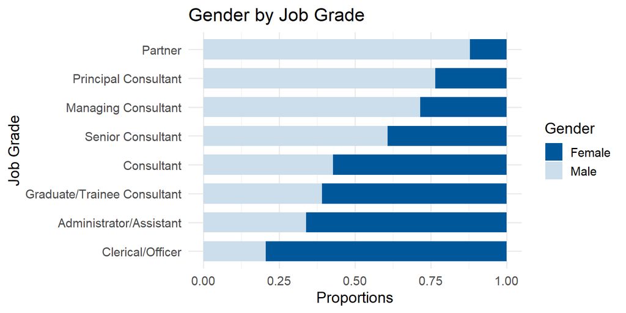

```r
ggplot(diversity1, aes(x=jobgrade, fill=gender))+
  geom_bar(position = "fill", width = 0.7)+
  labs(title = "Gender by Job Grade",
      x = "Job Grade",
      y = "Proportions",
      fill= "Gender")+
  theme_minimal(base_size = 14)+
  scale_fill_manual(values = c("Female" = "#00589b", "Male"= "#ccddeb"))+
  coord_flip()
```

## Are women underrepresented in senior leadership roles within the organization?

Up to this point, the data reveal a clear pattern: men are more common in senior roles, while women tend to occupy junior positions.

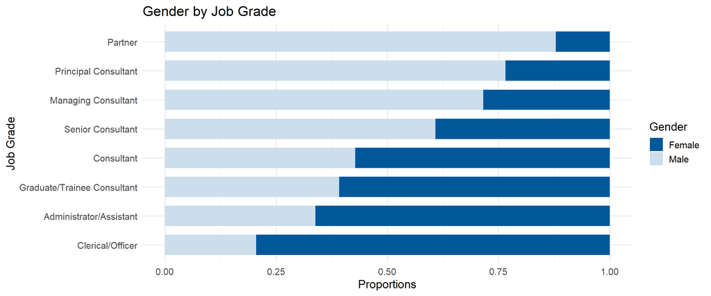

## Does this organization have a gender diversity issue?

- The data indicate a pattern where women are more commonly in junior roles and men in senior roles.
- However, it’s unclear from the data whether this pattern is coincidental or statistically significant.
- To assess this, we can employ a chi-squared test to determine the statistical significance of the observed pattern.

# Chi-Squared Test

## The hypotheses

**H0**: There is no association between gender and job grade within the organization.

- the observed distribution of females and males across job grades is due to random chance.

**H1**: There is a significant association between gender and job grade within the organization.

- the observed distribution of females and males across job grades is not a result of random chance; it reflects a significant pattern of male predominance in senior roles and a greater representation of females in entry-level positions.

## Chi squared test in R

```r
cross_tab <- table(diversity1$jobgrade, diversity1$gender)
chisq.test(cross_tab)
```

```
    Pearson's Chi-squared test

data:  cross_tab
X-squared = 164.7, df = 7, p-value < 2.2e-16
```

- The p-value is extremely small, less than 2.2e-16, which is very close to zero.
- Since the p-value is less than the significance level of 0.05, we can confidently reject the null hypothesis, concluding that the two variables are dependent.
- This result indicates a statistically significant association between gender and job grade.
- It suggests that certain factors are influencing the observed distribution of genders within job grades.

# Conclusions

## Recommendation

- While this statistical evidence does not directly imply a gender diversity issue within the organization, it signals that factors beyond chance influence the gender distribution across job grades.
- To address potential gender bias or discrimination and foster diversity and inclusion within the organization, further analysis and actions are necessary.